# Calibration Preview

Ernesto

July 26, 2017

## Calibration

I’ve been working on calibrating the West-Coast DTS model to the real data. I was asked to provide a preview today just so that we could see how far off we are from the mark.

Overall we have two sources of data * Fishery-wide data (landings, quotas, biomass, profits) * Logbook data Usually both are used as “inputs” to fix parameters, with calibration usually being tweaking a few key parameters for which we don’t have much information.  
Our approach is slightly different in the sense that we don’t want to use logbook data as a way to fit statistical agents but we’d rather have our simple agents adapt freely but tracing logbook data that is as similar to the real stuff as possible.

We do the calibration in two steps:  
1. Fix agents statistically: find catchabilities that generate correct landings 2. Free agents and calibrate them such that they replicate the original logbook data The idea in this exercise is pretty much to see how realistic we can get when all we have is our good old explore-exploit-imitate.

Here’s how the end-result looks like:

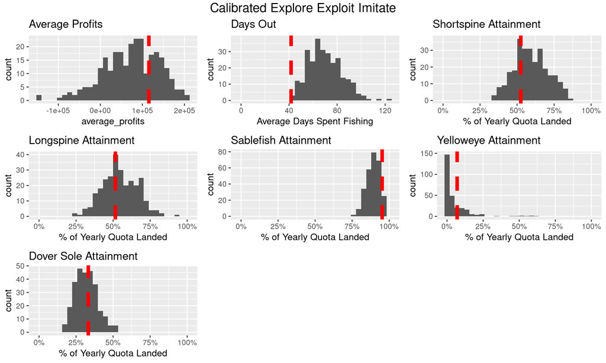

These are all histograms of 250 simulation runs. The red dotted line represents the empirical “real” value. The closer we are, the more “realistic” our model is.

As you can see, particularly for quota attainment (landings/total quota available), we tend to do a decent job. Dover Sole (which is the biggest landing in absolute terms) is centered aroud 33% like the empirics suggests, there is a lot more dispersion for Longspine and Shortspine but that’s because they tend to live together so that some simulation you get a bit more of one and a bit less of the other (also their stock assessment numbers are weird). Sablefish is the choke species as it should be, although sometimes the market is not efficient enough to get all the quota consumed. Yelloweye Rockfish is a bit weird in the sense that in most simulation it is never fished but in a few cases about half of the quota is. This is usually a disaster-tow situation.  
Where the simulation works a bit less well however is in profits and efficiency. Profits are heavily dispersed and in general the fishery takes 30 days longer than it should to end.

One interesting result however, is that when calibrated our agents are very risk-averse. Their exploration rate is only 3.5% which is very low.  
Moreover, it is trivial to find agents who would perform better in the same model. If we just increase exploration rate to 15% we get a much more “efficient” model:

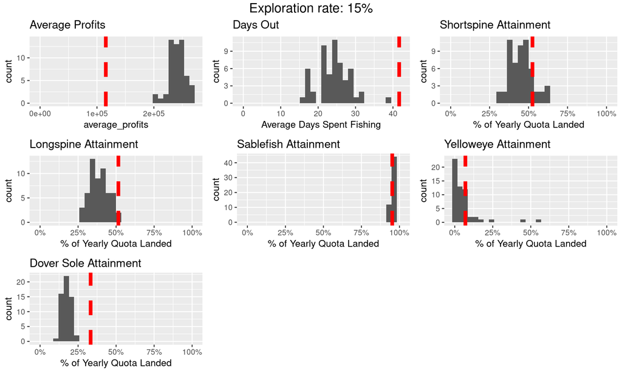

Now the fishery makes about twice the empirical profits in about half of the days. As the attainment plots show, what happens is that agents get a lot better at catching Sablefish without catching the other two species (Sole and Thornyheads).  
Why aren’t the fishers exploring more? There are two possible answers for this puzzle:

1. The model, by approximating movement, distances and habitats is creating fishing opportunities that are too good to be true and don’t actually exist in the real world
2. Fishers are not just perfect profit-maximizers.

We can’t really be sure just by running this single model implementation. If this result keeps cropping up then we might guess 2 is true. If this is an isolated result (or we judge the calibration not good enough) then we might think the first answer is more apt.

## Jansen’s trap

Whenever we run an ABM calibration there is always one big risk we should keep at the back of our mind: we calibrated the biological side so well (including fishing power, catchability and the like) that the behavioural part is pointless and that all the results are driven by the well calibrated biological layer.

That’s why I always think it’s a good idea to look at what the dashboard looks like when the biology layer is calibrated but the agents in our model make random decisions all the time. As you can see the fits are absolutely dreadful at that point:

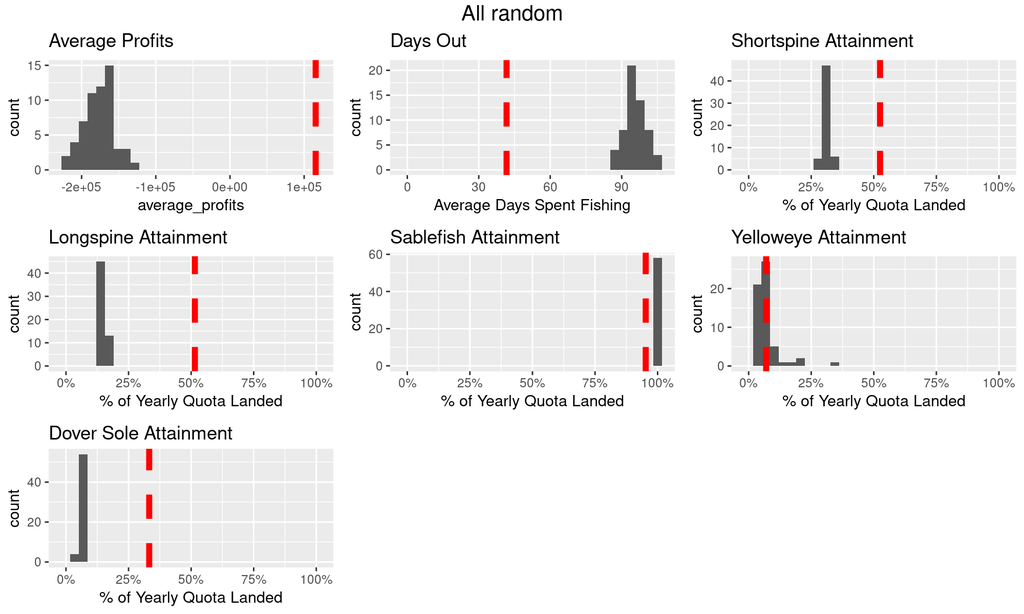

Fishery lasts 100 days, it is entirely in the red, most attainments are off except sablefish which is at 100% (but that’s just because one quota must always be consumed for the fishery to close).

This means that behaviour matters, a lot, in this fishery. If anything our model is too sensitive to changes in behaviour. This of course makes the whole process of calibrating very painful, but it is a nice validation of why ABMs are important (or even why we should study the human-side of fisheries).

## Statistical Agents

It is also worth studying what the model output looks like between step 1 and step 2 of the calibration. That is when we have finished finding the biological parameters (really the catchabilities) but we are still fixing agents to stats.

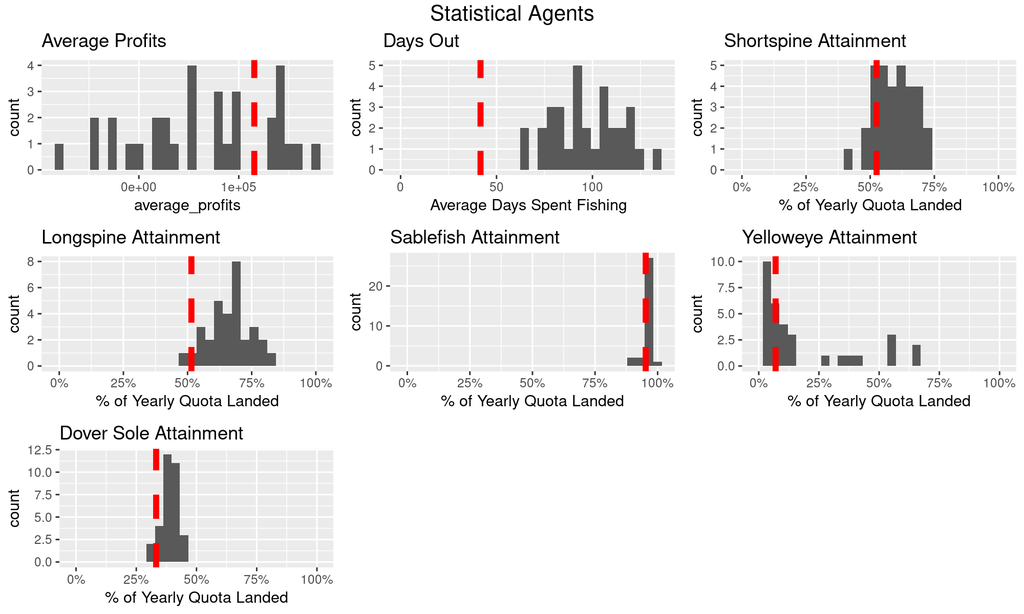

## What’s next?

To be honest, I could work on this stuff for years. There just is so much more to try. We only simulated the ITQ era, not the trip-limits years that preceded it. There probably is a lot more work that can be done with what we have trying to calibrate better the statistical agents (I am guessing sablefish movement is a prime driver here).